# By Whom does Prosper prosper

## by Josh King

## Dataset Overview

The analyzed dataset is a record of 113,937 data entries from Prosper Loans. The data includes a number of variables regarding each loan listing (81 variables in total). The full data set included metadata about each listing, details on the loans recording by each listing, and data related to the borrower who took out the loan. For the analysis here, we focus on data that helps us review anticipated loan returns based on loan amounts and the income of different borrowers.

## Investigation Overview

As part of my analysis, I investigated if and how a borrower's income bracket effected the estimated return on a Prosper loan. In this presentation I'll first demonstrate a trend of decreasing estimated return with increasing income bracket. Since this is a somewhat counter-intuitive result (one would expect higher earners able to produce higher yields on a loan), the presentation proceeds to show how this relationship is more a factor of the loan borrowing rate, with higher income brackets accessing a lower borrowing rate.

*For any slide with a relevant plot, press the down arrow key to review the relevant data. To review the associated code for any plot, click on that plot.*

## Income Range vs Estimated Return

To understand the discovered trend, we should first plot the income range against the estimated return on the loan. A box plot of this reveals a slight, but evident, trend of decreasing estimated return (by both distribution and median value) associated with increasing income brackets (for brackets higher than $0).

Interestingly the unemployed and $0 brackets break this trend with an even higher estimated return than the non-zero income brackets. We might have otherwise expected higher incomes to more securely produce a positive loan return, so let's investigate.

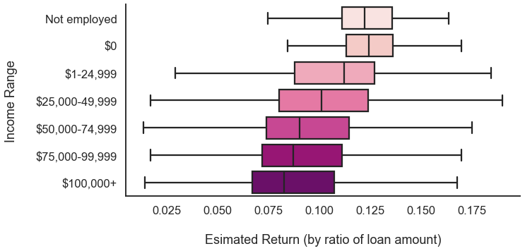

```python
plt.figure(figsize=[10,5])
sb.boxplot(data=df, y='IncomeRange', x='EstimatedReturn', order=income_order, palette=seq_color, showfliers=False)
sb.despine()
plt.xlabel("Esimated Return (by ratio of loan amount)", labelpad=25)
plt.ylabel("Income Range", labelpad=25)
plt.show()
```

## Income Range vs Borrower Rate

My initial intuition to explain the previously noted trend was that, perhaps, lower income earners borrowed at higher rates. Prosper might view these lower brackets as more "risky" and as such loan largely at higher rates. A plot of the income ranges vs borrowing rates indicates this trend to be true.

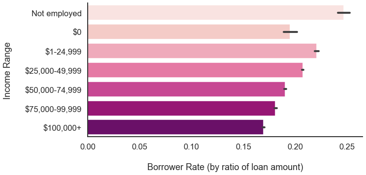

```python
plt.figure(figsize=[10,5])
sb.barplot(data=df, y='IncomeRange', x='BorrowerRate', order=income_order, palette=seq_color)
sb.despine()
plt.xlabel("Borrower Rate (by ratio of loan amount)", labelpad=25)
plt.ylabel("Income Range", labelpad=25)
plt.show()
```

## Estimated Return vs Loan Amount (Facetted Against Income)

So far my intuition about estimated return being more a matter of the borrower rate than income has seemed reasonable, but would the types of loans an income bracket takes out factor into this?

To review this, I facetted out the estimated return and loan amount for each income bracket. This facet grid of plots is large and hard to display on one slide, but you can review the whole plot below by pressing down. To show the data more clearly, I have plotted each facet on the grid individually on the following slides.

My expectation was that each income bracket would show the same relationship between estimated return and loan amount. If so, then I could continue with my proposed direction that the difference in estimated returns is more a factor of borrower rate on the loan than the income itself (even though we saw an initial, counter-intuitive income difference). If not, then income may have a more central role beyond that of the borrower rate.

The invidiual plots follow.

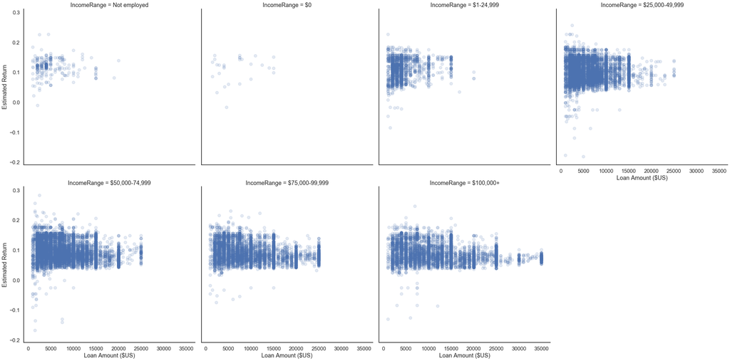

```python
sb.set_context('talk')

grid = sb.FacetGrid(data=df.sample(50000), col='IncomeRange', col_wrap=4,\
                    col_order=income_order, margin_titles=True, size=8)
grid.map(plt.scatter, 'LoanOriginalAmount', 'EstimatedReturn', alpha=.15)
grid.set_axis_labels("Loan Amount ($US)", "Estimated Return");

plt.show()
```

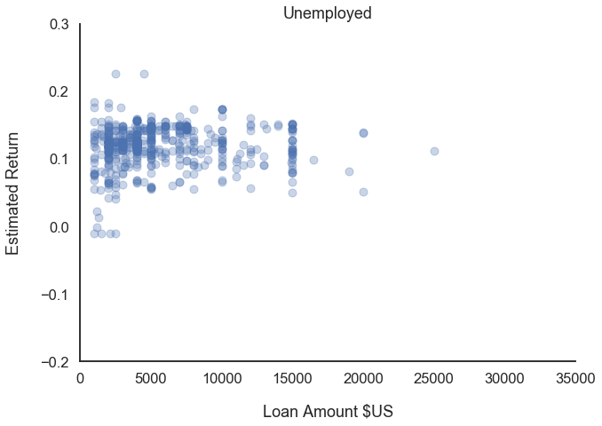

```python
plt.figure(figsize=[10,7])
sb.regplot(data=df.query('IncomeRange == "Not employed"'), x='LoanOriginalAmount', y='EstimatedReturn',
          fit_reg=False, scatter_kws={'alpha':0.3})

sb.despine()

plt.xlim(0, 35000)
plt.ylim(-0.2, 0.3)

plt.xlabel("Loan Amount $US", labelpad=20)
plt.ylabel("Estimated Return", labelpad=20)
plt.title("Unemployed")

plt.show()
```

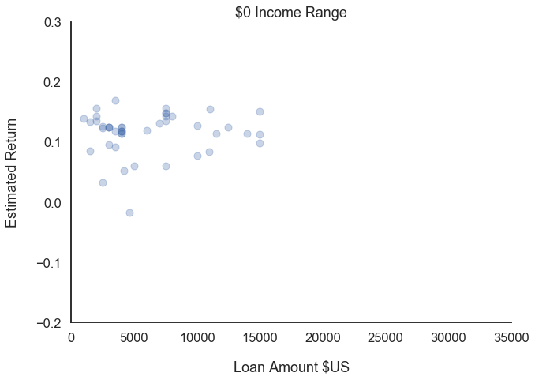

```python
plt.figure(figsize=[10,7])
sb.regplot(data=df.query('IncomeRange == "$0"'), x='LoanOriginalAmount', y='EstimatedReturn',
          fit_reg=False, scatter_kws={'alpha':0.3})

sb.despine()

plt.xlim(0, 35000)
plt.ylim(-0.2, 0.3)

plt.xlabel("Loan Amount $US", labelpad=20)
plt.ylabel("Estimated Return", labelpad=20)
plt.title("$0 Income Range")

plt.show()
```

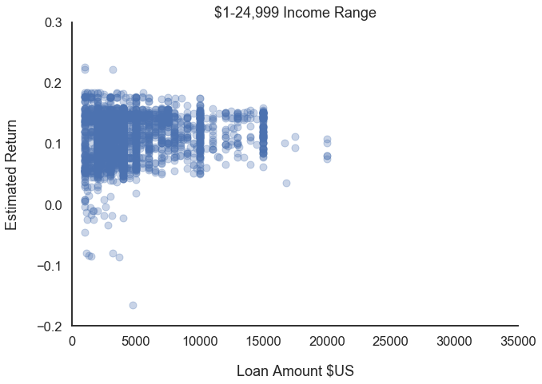

```python
plt.figure(figsize=[10,7])
sb.regplot(data=df.query('IncomeRange == "$1-24,999"'), x='LoanOriginalAmount', y='EstimatedReturn',
          fit_reg=False, scatter_kws={'alpha':0.3})

sb.despine()

plt.xlim(0, 35000)
plt.ylim(-0.2, 0.3)

plt.xlabel("Loan Amount $US", labelpad=20)
plt.ylabel("Estimated Return", labelpad=20)
plt.title("$1-24,999 Income Range")

plt.show()
```

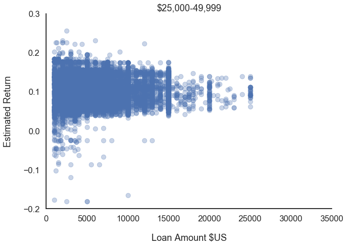

```python
plt.figure(figsize=[10,7])
sb.regplot(data=df.query('IncomeRange == "$25,000-49,999"'), x='LoanOriginalAmount', y='EstimatedReturn',
          fit_reg=False, scatter_kws={'alpha':0.3})

sb.despine()

plt.xlim(0, 35000)
plt.ylim(-0.2, 0.3)

plt.xlabel("Loan Amount $US", labelpad=20)
plt.ylabel("Estimated Return", labelpad=20)
plt.title("$25,000-49,999")

plt.show()
```

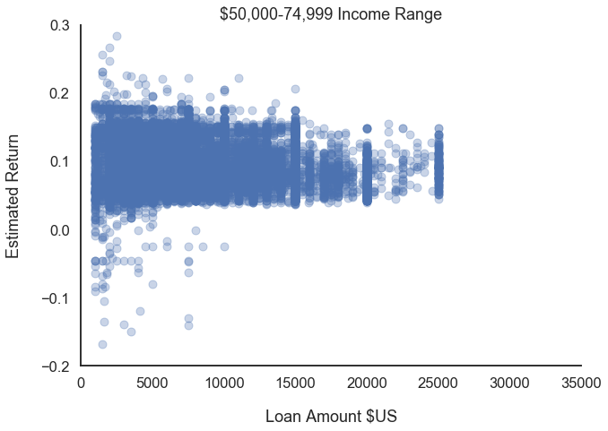

```python
plt.figure(figsize=[10,7])
sb.regplot(data=df.query('IncomeRange == "$50,000-74,999"'), x='LoanOriginalAmount', y='EstimatedReturn',
          fit_reg=False, scatter_kws={'alpha':0.3})

sb.despine()

plt.xlim(0, 35000)
plt.ylim(-0.2, 0.3)

plt.xlabel("Loan Amount $US", labelpad=20)
plt.ylabel("Estimated Return", labelpad=20)
plt.title("$50,000-74,999 Income Range")

plt.show()
```

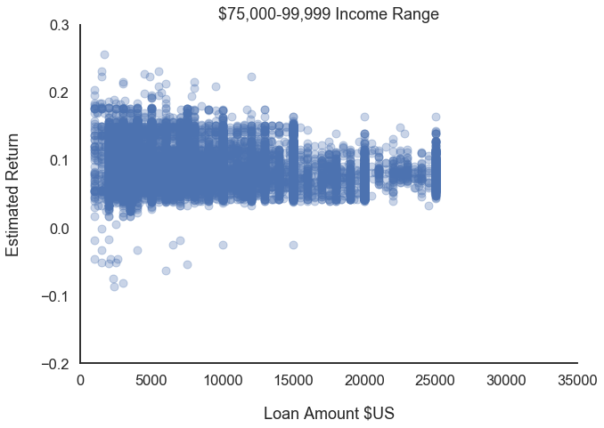

```python
plt.figure(figsize=[10,7])
sb.regplot(data=df.query('IncomeRange == "$75,000-99,999"'), x='LoanOriginalAmount', y='EstimatedReturn',
          fit_reg=False, scatter_kws={'alpha':0.3})

sb.despine()

plt.xlim(0, 35000)
plt.ylim(-0.2, 0.3)

plt.xlabel("Loan Amount $US", labelpad=20)
plt.ylabel("Estimated Return", labelpad=20)
plt.title("$75,000-99,999 Income Range")

plt.show()
```

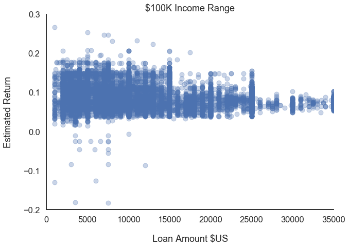

```python
plt.figure(figsize=[10,7])
sb.regplot(data=df.query('IncomeRange == "$100,000+"'), x='LoanOriginalAmount', y='EstimatedReturn',
          fit_reg=False, scatter_kws={'alpha':0.3})

sb.despine()

plt.xlim(0, 35000)
plt.ylim(-0.2, 0.3)

plt.xlabel("Loan Amount $US", labelpad=20)
plt.ylabel("Estimated Return", labelpad=20)
plt.title("$100K Income Range")

plt.show()
```

## Facet Grid Results

A couple of things stood out when reviewing the facetted return and loan amount data on each income bracket. First, the relationship between estimated return and loan amount did remain similar across all brackets. However, it became clear that increasing income brackets had access to higher loan amounts. Interestingly, the estimated returns on these higher loan amounts (for all income brackets) were comparatively lower but still positive.

This does support the previous supposition, but it adds an additional consideration of loan amount which we'll review in the next plot.

## Bringing it all together (Estimated Return, Loan Amount, and Borrowing Rate)

The previous analysis has now painted a picture that the estimated return is indeed more likely controlled by borrowing rate, with some consideration given to loan amount. To bring this all together, I plotted each of these variables (plot below) with the borrowing rate encoded by color (high values in yellow, low values in dark blue).

With the exception of a few outliers having negative estimated returns, the highest estimated returns are indeed well-associated with higher borrowing rates. The plotted distribution shows a nice gradient from blue to yellow as the estimated return increases. Even more interesting, the highest estimated returns are all clustered at relatively low loan amounts and high borrowing rates located in the top left of the plot.

We can now make an educated argument about why lower income brackets have a higher estimated return than higher income brackets. First, lower income earners are more likely to take out smaller loans and have higher borrowing rates. Due to either the income range or the loan amount itself, Prosper loans these at higher rates, resulting in a higher estimated return rate. Conversely, higher income brackets (either by income or due to the volume loaned) likely qualify for lower borrowing rates resulting in a lower return. To the extent that income affects estimated return, it is indirectly through variables like borrowing rate or loan amount.

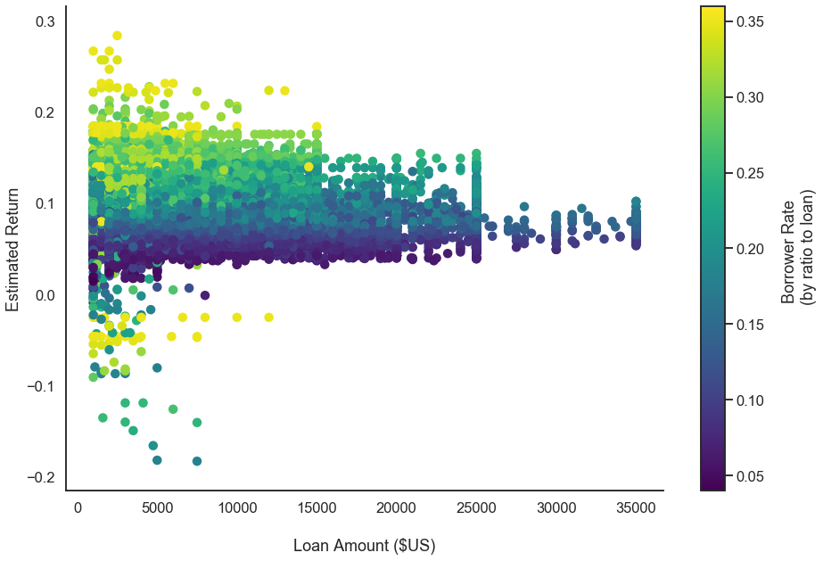

```python
sb.set_context('talk')

plt.figure(figsize=[15,10])
plt.scatter(data=df.sample(50000), x='LoanOriginalAmount', y='EstimatedReturn', c='BorrowerRate', cmap='viridis')
plt.xlabel("Loan Amount ($US)", labelpad=25)
plt.ylabel("Estimated Return")

sb.despine()

cbar = plt.colorbar()
cbar.set_label("Borrower Rate \n (by ratio to loan)", labelpad=20)

plt.show()
```